# Práctica 9. Análisis de texto

## Objetivo

Explorar los comentarios escritos en el dataset de reseñas de recetas mediante limpieza y análisis de texto. Se generará una **nube de palabras**, se identificarán términos y expresiones frecuentes y se examinará la longitud de los comentarios y su relación descriptiva con la calificación.

> Los comentarios originales están escritos principalmente en inglés. Por ello, la limpieza y las palabras vacías se configuran para ese idioma; las explicaciones y conclusiones de la práctica están en español.

Coloca `dataset_limpio.csv` en la misma carpeta que este notebook antes de ejecutarlo. Para generar la nube se necesita `wordcloud` (`%pip install wordcloud` si aún no está instalado).

```python
import re
import html
from collections import Counter

import numpy as np
import pandas as pd
import matplotlib.pyplot as plt
from bs4 import BeautifulSoup
from sklearn.feature_extraction.text import ENGLISH_STOP_WORDS, CountVectorizer
from wordcloud import WordCloud, STOPWORDS

RUTA_DATOS = "dataset_limpio.csv"
df = pd.read_csv(RUTA_DATOS)
print(f"Dimensiones del dataset: {df.shape}")
print(f"Comentarios con texto: {df['text'].notna().sum():,}")
df[["recipe_name", "stars", "has_comment_text", "text"]].head()
```

```
Dimensiones del dataset: (18182, 17)
Comentarios con texto: 18,180
```

|  | recipe_name | stars | has_comment_text | text |
| --- | --- | --- | --- | --- |
| 0 | Creamy White Chili | 5 | True | <p>A favorite of my hubby. He loves the flavor... |
| 1 | Chocolate Guinness Cake | 4 | True | <p>Any ideas for non-alcoholic substitute for ... |
| 2 | Creamy White Chili | 5 | True | <p>Awesome!!!!!!!!!!!!!!!!!!!!!!</p> |
| 3 | Moist Chocolate Cake | 5 | True | <p>ABSOLUTELY DELCIOUS! And so easy to make! ... |
| 4 | Baked Mushroom Chicken | 4 | True | <p>Chicken is tender and very good. One of my ... |

## 1. Limpieza del texto

La columna `text` contiene fragmentos HTML. Se convierten a texto plano, se normalizan a minúsculas y se conservan letras y espacios. Las entradas vacías se excluyen del análisis textual. No se modifica la columna original.

```python
def limpiar_texto(valor):
    if pd.isna(valor):
        return ""
    texto = BeautifulSoup(html.unescape(str(valor)), "html.parser").get_text(" ")
    texto = texto.lower()
    texto = re.sub(r"https?://\S+|www\.\S+", " ", texto)
    texto = re.sub(r"[^a-z\s]", " ", texto)
    return re.sub(r"\s+", " ", texto).strip()

df["texto_limpio"] = df["text"].apply(limpiar_texto)
df_texto = df.loc[df["texto_limpio"].str.len() > 0].copy()
df_texto["numero_palabras"] = df_texto["texto_limpio"].str.split().str.len()
print(f"Comentarios con texto no vacío: {len(df_texto):,}")
print(f"Textos vacíos o sin contenido después de limpiar: {(df['texto_limpio'].str.len() == 0).sum():,}")
df_texto[["text", "texto_limpio", "numero_palabras"]].head()
```

```
Comentarios con texto no vacío: 18,164
Textos vacíos o sin contenido después de limpiar: 18
```

|  | text | texto_limpio | numero_palabras |
| --- | --- | --- | --- |
| 0 | <p>A favorite of my hubby. He loves the flavor... | a favorite of my hubby he loves the flavor of ... | 16 |
| 1 | <p>Any ideas for non-alcoholic substitute for ... | any ideas for non alcoholic substitute for the... | 12 |
| 2 | <p>Awesome!!!!!!!!!!!!!!!!!!!!!!</p> | awesome | 1 |
| 3 | <p>ABSOLUTELY DELCIOUS! And so easy to make! ... | absolutely delcious and so easy to make i just... | 48 |
| 4 | <p>Chicken is tender and very good. One of my ... | chicken is tender and very good one of my favo... | 28 |

## 2. Descripción general de los comentarios

Se revisan la cantidad de textos, el número de palabras y la distribución de longitud. El promedio puede verse afectado por comentarios muy extensos, por lo que también se informa la mediana.

```python
resumen_texto = pd.Series({
    "Comentarios analizados": len(df_texto),
    "Palabras totales": int(df_texto["numero_palabras"].sum()),
    "Promedio de palabras por comentario": df_texto["numero_palabras"].mean(),
    "Mediana de palabras por comentario": df_texto["numero_palabras"].median(),
    "Máximo de palabras en un comentario": df_texto["numero_palabras"].max(),
})
resumen_texto
```

```
Comentarios analizados                  18164.000000
Palabras totales                       691056.000000
Promedio de palabras por comentario        38.045364
Mediana de palabras por comentario         30.000000
Máximo de palabras en un comentario       506.000000
dtype: float64
```

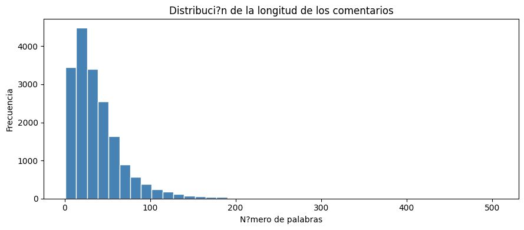

```python
plt.figure(figsize=(9, 4))
plt.hist(df_texto["numero_palabras"], bins=40, color="steelblue", edgecolor="white")
plt.title("Distribución de la longitud de los comentarios")
plt.xlabel("Número de palabras")
plt.ylabel("Frecuencia")
plt.tight_layout()
plt.show()
```

## 3. Palabras más frecuentes

Se eliminan palabras funcionales comunes en inglés (por ejemplo, *the*, *and* y *is*) para destacar términos con mayor contenido. Se añaden algunas palabras frecuentes propias de comentarios de recetas que suelen aportar poca información temática.

```python
palabras_vacias = set(ENGLISH_STOP_WORDS) | set(STOPWORDS) | {
    "recipe", "recipes", "make", "made", "use", "used", "will", "one",
    "just", "really", "like", "also", "get", "would", "can", "much"
}

frecuencias = Counter(
    palabra
    for texto in df_texto["texto_limpio"]
    for palabra in texto.split()
    if len(palabra) > 2 and palabra not in palabras_vacias
)
frecuencias_df = pd.DataFrame(frecuencias.most_common(20), columns=["palabra", "frecuencia"])
frecuencias_df
```

|  | palabra | frecuencia |
| --- | --- | --- |
| 0 | good | 3648 |
| 1 | time | 3177 |
| 2 | delicious | 3141 |
| 3 | great | 3020 |
| 4 | easy | 2835 |
| 5 | added | 2818 |
| 6 | family | 2550 |
| 7 | loved | 2265 |
| 8 | cake | 1972 |
| 9 | love | 1941 |
| 10 | add | 1903 |
| 11 | instead | 1838 |
| 12 | soup | 1808 |
| 13 | cheese | 1705 |
| 14 | chicken | 1703 |
| 15 | sugar | 1668 |
| 16 | sauce | 1629 |
| 17 | bread | 1619 |
| 18 | making | 1616 |
| 19 | cream | 1520 |

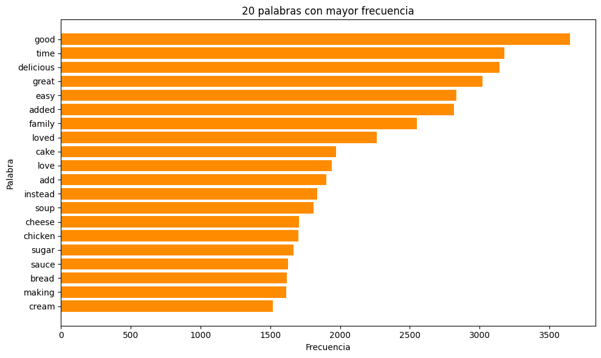

```python
plt.figure(figsize=(10, 6))
plt.barh(frecuencias_df["palabra"].iloc[::-1], frecuencias_df["frecuencia"].iloc[::-1], color="darkorange")
plt.title("20 palabras con mayor frecuencia")
plt.xlabel("Frecuencia")
plt.ylabel("Palabra")
plt.tight_layout()
plt.show()
```

## 4. Nube de palabras

El tamaño de cada palabra representa su frecuencia relativa en el corpus limpio. La nube sirve como resumen visual, pero no conserva el orden de las palabras ni el contexto de las frases; por eso se complementa con las tablas y gráficas anteriores.

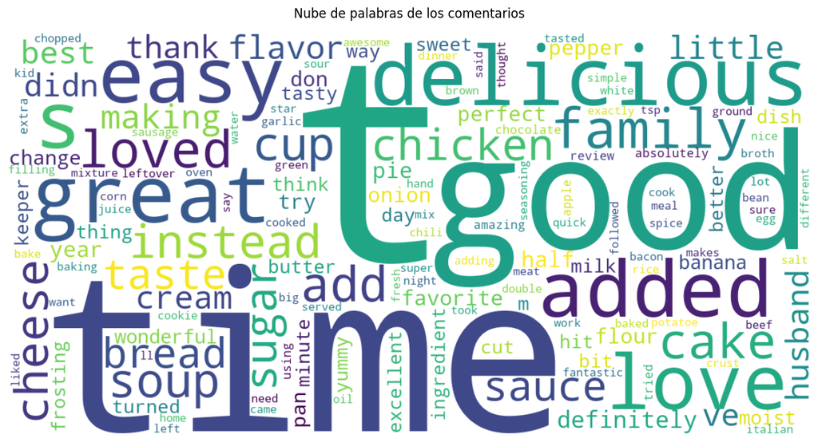

```python
texto_corpus = " ".join(df_texto["texto_limpio"])
nube = WordCloud(
    width=1200,
    height=600,
    background_color="white",
    stopwords=palabras_vacias,
    max_words=150,
    collocations=False,
    random_state=42,
    colormap="viridis",
).generate(texto_corpus)

plt.figure(figsize=(14, 7))
plt.imshow(nube, interpolation="bilinear")
plt.axis("off")
plt.title("Nube de palabras de los comentarios", pad=15)
plt.show()
```

## 5. Longitud de comentarios según calificación

Se comparan las longitudes únicamente para reseñas con estrellas válidas (de 1 a 5). Esta comparación es descriptiva: no demuestra que la calificación cause comentarios más largos o más cortos.

```python
df_texto["stars"] = pd.to_numeric(df_texto["stars"], errors="coerce")
con_calificacion = df_texto.loc[df_texto["stars"].between(1, 5)].copy()
resumen_estrellas = (
    con_calificacion.groupby("stars")["numero_palabras"]
    .agg(cantidad="count", promedio="mean", mediana="median")
    .round(2)
)
resumen_estrellas
```

| stars | cantidad | promedio | mediana |
| --- | --- | --- | --- |
| 1 | 280 | 39.00 | 30.0 |
| 2 | 232 | 44.08 | 34.0 |
| 3 | 489 | 43.22 | 37.0 |
| 4 | 1653 | 42.70 | 34.0 |
| 5 | 13817 | 37.97 | 30.0 |

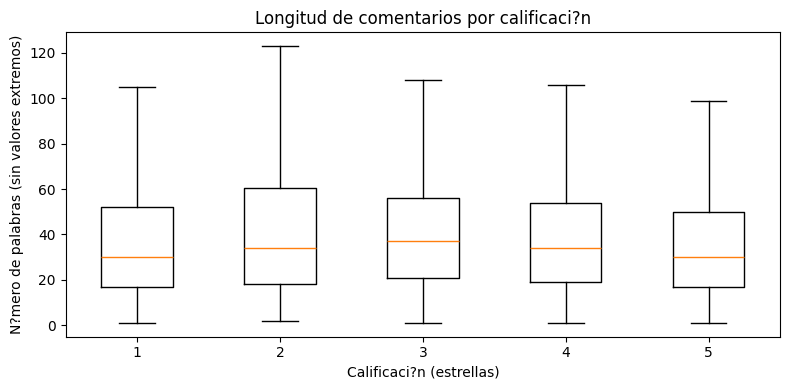

```python
orden_estrellas = sorted(con_calificacion["stars"].dropna().unique())
datos_cajas = [con_calificacion.loc[con_calificacion["stars"] == estrella, "numero_palabras"] for estrella in orden_estrellas]
plt.figure(figsize=(8, 4))
plt.boxplot(datos_cajas, tick_labels=[int(e) for e in orden_estrellas], showfliers=False)
plt.title("Longitud de comentarios por calificación")
plt.xlabel("Calificación (estrellas)")
plt.ylabel("Número de palabras (sin valores extremos)")
plt.tight_layout()
plt.show()
```

## 6. Expresiones frecuentes (bigramas)

Además de palabras individuales, se cuentan pares de palabras consecutivas. Esto aporta algo de contexto, aunque sigue sin sustituir la lectura cualitativa de los comentarios.

```python
vectorizador = CountVectorizer(
    stop_words=list(palabras_vacias),
    ngram_range=(2, 2),
    min_df=3,
    max_features=20,
)
matriz_bigrama = vectorizador.fit_transform(df_texto["texto_limpio"])
frecuencia_bigrama = np.asarray(matriz_bigrama.sum(axis=0)).ravel()
bigramas_df = pd.DataFrame({
    "expresion": vectorizador.get_feature_names_out(),
    "frecuencia": frecuencia_bigrama,
}).sort_values("frecuencia", ascending=False).reset_index(drop=True)
bigramas_df
```

|  | expresion | frecuencia |
| --- | --- | --- |
| 0 | sour cream | 522 |
| 1 | family loved | 466 |
| 2 | banana bread | 400 |
| 3 | cream cheese | 396 |
| 4 | brown sugar | 353 |
| 5 | family loves | 303 |
| 6 | ground beef | 271 |
| 7 | absolutely delicious | 256 |
| 8 | chicken broth | 254 |
| 9 | easy delicious | 250 |
| 10 | family favorite | 248 |
| 11 | quick easy | 244 |
| 12 | taste home | 222 |
| 13 | thanks sharing | 206 |
| 14 | husband loved | 204 |
| 15 | turned great | 199 |
| 16 | big hit | 196 |
| 17 | peanut butter | 186 |
| 18 | definitely making | 181 |
| 19 | making years | 180 |

## 7. Conclusiones

Completa las conclusiones después de observar las salidas del notebook:

- Las palabras con mayor frecuencia reflejan los temas o términos dominantes en los comentarios, una vez eliminadas las palabras vacías.
- La nube facilita la identificación visual de esos términos, mientras que las tablas muestran sus frecuencias exactas.
- La distribución de longitud puede ser asimétrica; por ello se consideran tanto promedio como mediana.
- La comparación por estrellas describe diferencias observadas en la muestra y no establece causalidad.
- La limpieza elimina HTML y puntuación, pero puede descartar señales útiles como emojis, énfasis o ciertas expresiones; los resultados dependen de estas decisiones.
- Los bigramas aportan contexto local, aunque para estudiar opiniones o temas con más profundidad sería conveniente aplicar análisis de sentimientos o modelado de tópicos.